# Handling imbalanced classes

Harsha Achyuthuni

05/09/2020

## What are imbalanced classes

Imbalanced classes is a significant issue in classification problems. Class imbalance happens when the dependant variable has one class with a higher frequency compared to the lower class. Take an example of the below data.

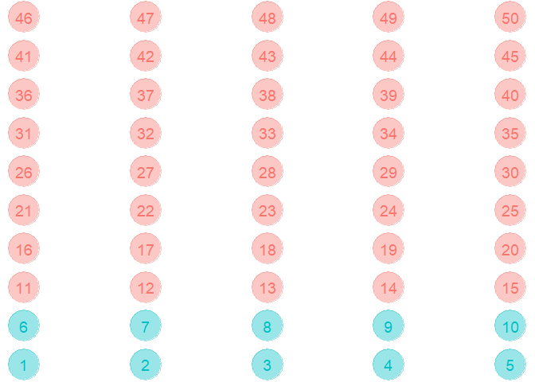

In this data, the class in blue is the minority class with a class imbalance of 10/40 = 25%. Such behaviour is observed in various problems such as:  
1. Fraud detection  
2. Conversion prediction  
3. Spam detection  
4. Churn prediction  
5. Outlier detection  
Each of these problem statements is binary class problems with the minority class having a significantly lower frequency than the majority class. Despite this, the prediction of the minority class is more important.

## How to resolve this issue?

### Upsampling

In up-sampling, we randomly sample (with replacement) the minority class to be the same size as the majority class. While this retains the full information of both the classes, the size of the data will become much larger. This can cause data handling and speed issues.

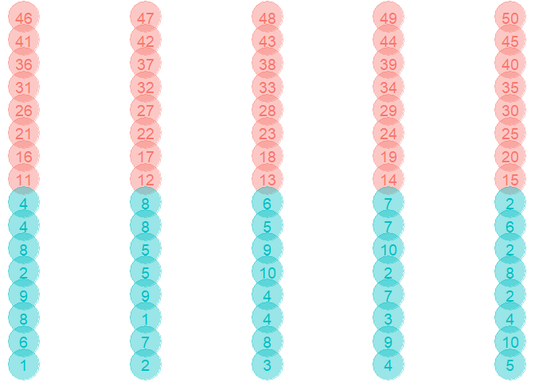

### Downsampling

In down-sampling, we subset the majority class in such a way that their frequency is similar to the minority class. This will create a smaller data-set which is easier to train, but the information from the majority class can be lost.

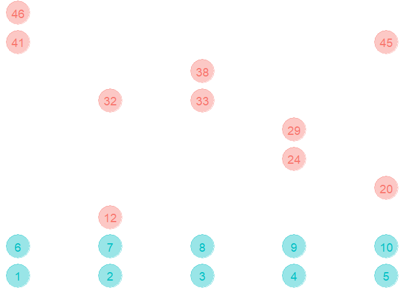

### SMOTE Sampling

SMOTE is a technique which down-sample the majority class and synthesises new data points in the minority class. SMOTE stands for Synthetic Minority Over-sampling Technique. Refer [this paper](https://www.jair.org/index.php/jair/article/view/10302) for more.

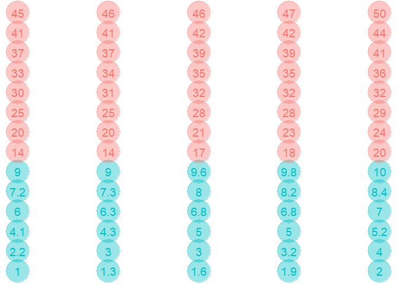

### ROSE Sampling

ROSE sampling is another synthetic sampling technique which creates synthetic minority and majority classes to handle an imbalance in the dataset. Read [this paper](https://link.springer.com/article/10.1007/s10618-012-0295-5) for more.

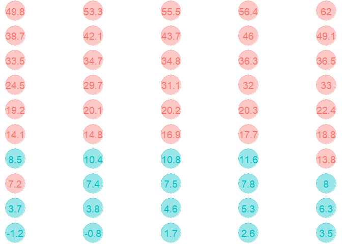

## References

1. Menardi, G., Torelli, N. Training and assessing classification rules with imbalanced data. Data Min Knowl Disc 28, 92–122 (2014).
2. Chawla, N.V., Bowyer, K.W., Hall, L.O. and Kegelmeyer, W.P., 2002. SMOTE: synthetic minority over-sampling technique. Journal of artificial intelligence research, 16, pp.321-357.
3. Caret documentation: https://topepo.github.io/caret/subsampling-for-class-imbalances.html